# HW 1: Cleaning UFO Data

### Plotting Review Fun

##13. Can you make a scatter plot of all encounters after 2013 occurring in the us?

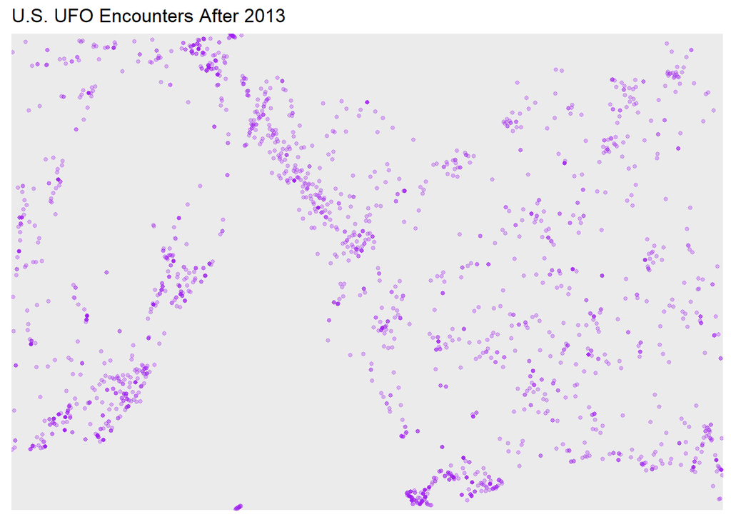

```r
# Filter and plot encounters after 2013 in the U.S.
# plot them by longitude and latitude. Reduces visual clutter with blank axes and light styling. use geom_point(alpha = 0.3, size = 1) to keep it light and readable
ufo %>%
  filter(country == "us", year > 2013) %>%
  ggplot(aes(x = longitude, y = latitude)) +
  geom_point(alpha = 0.3, size = 1, color = "purple") +
  labs(
    title = "U.S. UFO Encounters After 2013",
    x = NULL,
    y = NULL
  ) +
  theme_minimal() +
  theme(
    axis.text.x = element_blank(),  # remove x-axis text
    axis.ticks.x = element_blank(), # remove x-axis ticks
    axis.text.y = element_blank(),  # remove y-axis text
    axis.ticks.y = element_blank()  # remove y-axis ticks
  )
```

### Practice with Forcats

https://forcats.tidyverse.org/

##14. What are the most common `shapes` of ufos for the `state` of Texas? (first try with counts())

```r
library(forcats)

# Count shapes in Texas
ufo %>%
  filter(state == "tx") %>%
  count(shape, sort = TRUE)
```

```
## # A tibble: 23 × 2
##    shape        n
##    <chr>    <int>
##  1 light      807
##  2 triangle   410
##  3 circle     345
##  4 other      331
##  5 unknown    328
##  6 disk       277
##  7 sphere     233
##  8 fireball   228
##  9 oval       221
## 10 cigar      121
## # ℹ 13 more rows
```

```r
# for plotting these shapes or further analsis, we can reorder them:
ufo %>%
  filter(state == "tx") %>%
  mutate(shape = fct_infreq(shape)) %>%
  count(shape)
```

```
## # A tibble: 23 × 2
##    shape        n
##    <fct>    <int>
##  1 light      807
##  2 triangle   410
##  3 circle     345
##  4 other      331
##  5 unknown    328
##  6 disk       277
##  7 sphere     233
##  8 fireball   228
##  9 oval       221
## 10 cigar      121
## # ℹ 13 more rows
```

##15. Can you make barplot displaying this information? (this time using forcats)

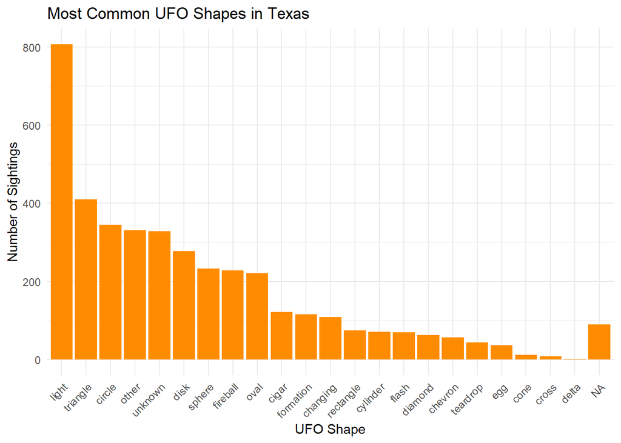

```r
ufo %>%
  filter(state == "tx") %>%
  mutate(shape = fct_infreq(shape)) %>%  # reorder shapes by frequency
  count(shape) %>%
  ggplot(aes(x = shape, y = n)) +
  geom_col(fill = "darkorange") +
  labs(
    title = "Most Common UFO Shapes in Texas",
    x = "UFO Shape",
    y = "Number of Sightings"
  ) +
  theme_minimal() +
  theme(axis.text.x = element_text(angle = 45, hjust = 1))
```

##16. Can you make the barplot ordered by counts?

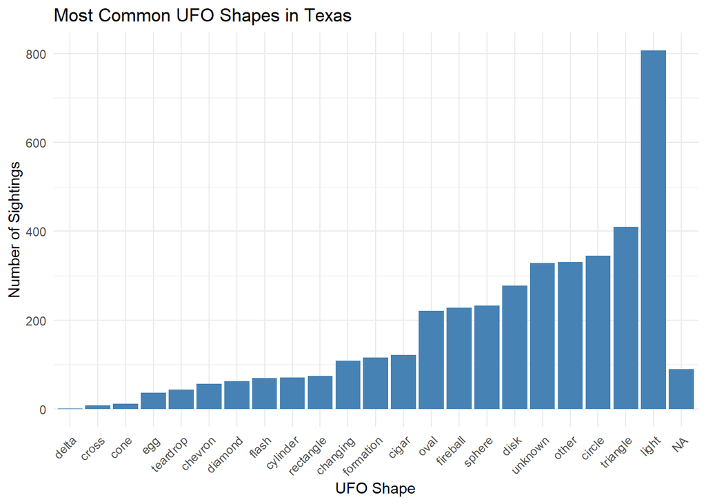

```r
#To make sure the barplot is ordered by counts, apply fct_infreq() inside the aes() call (or relevel the factor before plotting)
ufo %>%
  filter(state == "tx") %>%
  count(shape) %>%
  mutate(shape = fct_reorder(shape, n)) %>%  # reorder shapes by count
  ggplot(aes(x = shape, y = n)) +
  geom_col(fill = "steelblue") +
  labs(
    title = "Most Common UFO Shapes in Texas",
    x = "UFO Shape",
    y = "Number of Sightings"
  ) +
  theme_minimal() +
  theme(axis.text.x = element_text(angle = 45, hjust = 1))
```

##17. This might display too many items for a concise plot. Can you reduce the count categories and replot?

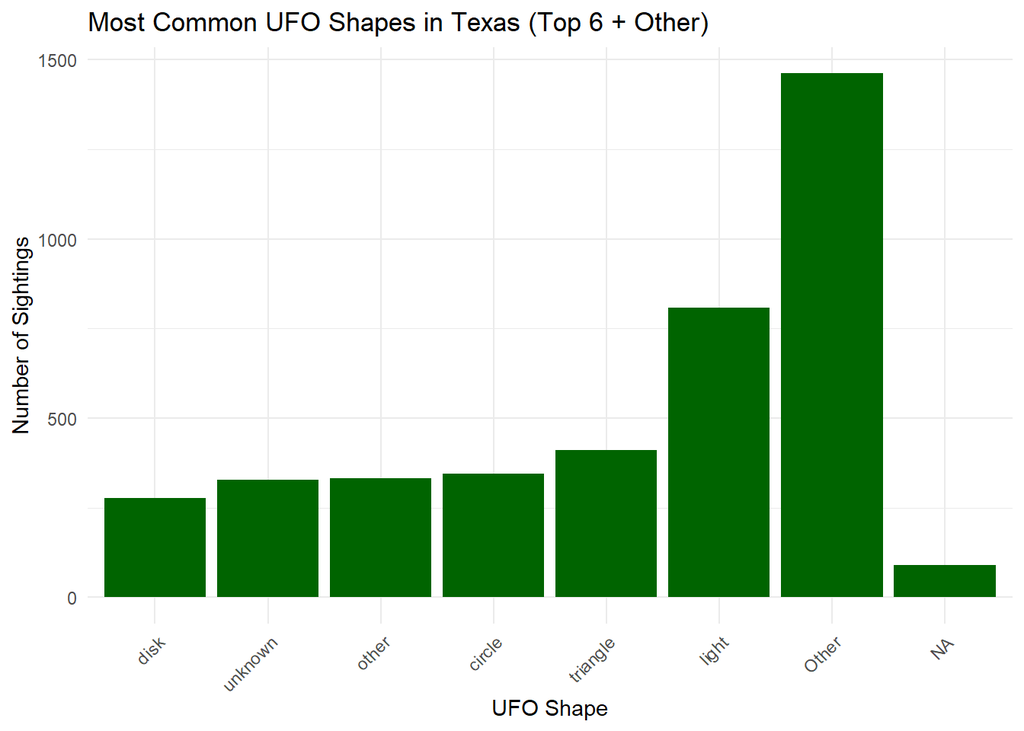

```r
# To reduce the count categories, like n = 6, and simplify the barplot, use forcats::fct_lump() to group less common shapes into an "Other" category — then replot
ufo %>%
  filter(state == "tx") %>%
  mutate(shape = fct_lump(shape, n = 6)) %>%  # keep top 6 shapes, lump rest into "Other"
  count(shape) %>%
  mutate(shape = fct_reorder(shape, n)) %>%
  ggplot(aes(x = shape, y = n)) +
  geom_col(fill = "darkgreen") +
  labs(
    title = "Most Common UFO Shapes in Texas (Top 6 + Other)",
    x = "UFO Shape",
    y = "Number of Sightings"
  ) +
  theme_minimal() +
  theme(axis.text.x = element_text(angle = 45, hjust = 1))
```

##18. What was the most common shape for Texas? How about Texas in the year 2010?

```r
# To find the most common UFO shape in Texas overall, and then specifically in Texas during the year 2010, use filter() + count() + slice_max()
# Overall most common shape in Texas
ufo %>%
  filter(state == "tx", !is.na(shape)) %>%
  count(shape, sort = TRUE) %>%
  slice_max(n, n = 1)
```

```
## # A tibble: 1 × 2
##   shape     n
##   <chr> <int>
## 1 light   807
```

```r
# Most common shape in Texas in 2010
ufo %>%
  filter(state == "tx", year == 2010, !is.na(shape)) %>%
  count(shape, sort = TRUE) %>%
  slice_max(n, n = 1)
```

```
## # A tibble: 1 × 2
##   shape     n
##   <chr> <int>
## 1 light    43
```